# Homework #7

Kylie Finnegan

2023-03-08

# Simulating and fitting data distributions

## Read in data vector: generate some fake data

```r
# quick and dirty, a truncated normal distribution to work on the solution set

z <- rnorm(n=3000, mean=0.2)
z <- data.frame(1:3000, z)
names(z) <- list("ID", "myVar")
z <- z[z$myVar > 0,]
str(z)
```

```
## 'data.frame':    1761 obs. of  2 variables:
##  $ ID   : int  2 3 6 7 9 10 11 12 14 16 ...
##  $ myVar: num  1.732 1.293 0.904 0.763 0.234 ...
```

```r
summary(z$myVar)
```

```
##     Min.  1st Qu.   Median     Mean  3rd Qu.     Max.
## 0.002037 0.348634 0.723415 0.860232 1.251786 4.517147
```

## Plot histogram of data

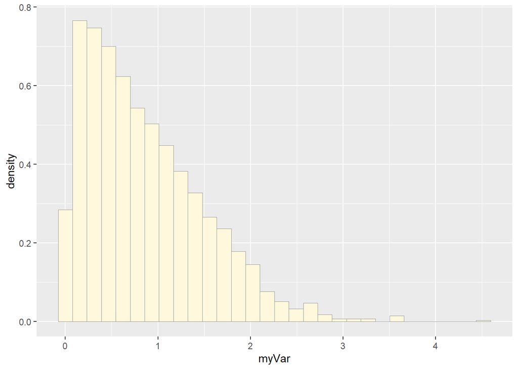

```r
p1 <- ggplot(data=z, aes(x=myVar, y=..density..)) +
  geom_histogram(color="grey60", fill="cornsilk",
                 linewidth=0.2)
print(p1)
```

## Add empirical density curve

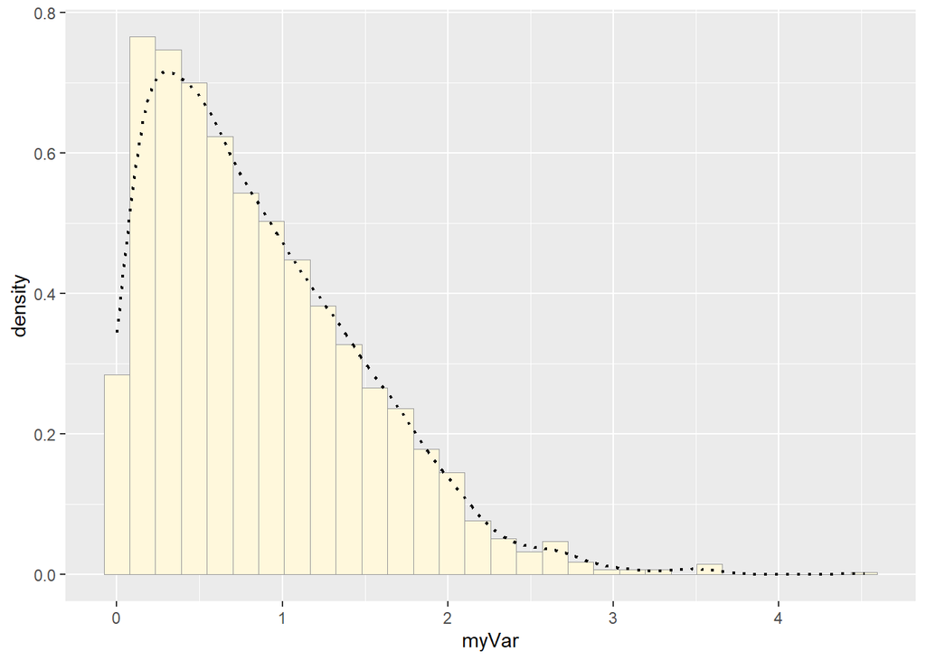

```r
p1 <- p1 + geom_density(linetype="dotted", size=0.75)
print(p1)
```

## Get maximum likelihood parameters for normal

```r
normPars <- fitdistr(z$myVar, "normal")
print(normPars)
```

```
##       mean          sd
##   0.86023157   0.63809548
##  (0.01520568) (0.01075204)
```

```r
str(normPars)
```

```
## List of 5
##  $ estimate: Named num [1:2] 0.86 0.638
##   ..- attr(*, "names")= chr [1:2] "mean" "sd"
##  $ sd      : Named num [1:2] 0.0152 0.0108
##   ..- attr(*, "names")= chr [1:2] "mean" "sd"
##  $ vcov    : num [1:2, 1:2] 0.000231 0 0 0.000116
##   ..- attr(*, "dimnames")=List of 2
##   .. ..$ : chr [1:2] "mean" "sd"
##   .. ..$ : chr [1:2] "mean" "sd"
##  $ n       : int 1761
##  $ loglik  : num -1708
##  - attr(*, "class")= chr "fitdistr"
```

```r
normPars$estimate["mean"]
```

```
##      mean
## 0.8602316
```

## Plot normal probability density

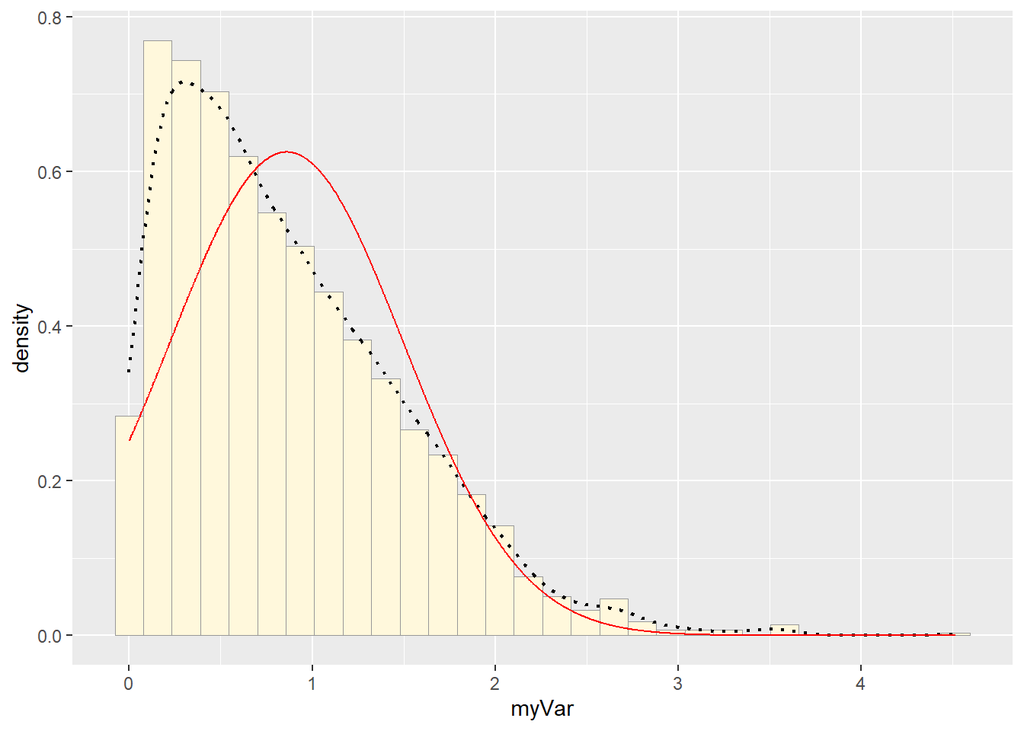

```r
meanML <- normPars$estimate["mean"]
sdML <- normPars$estimate["sd"]
xval <- seq(0,max(z$myVar), len=length(z$myVar))
stat <- stat_function(aes(x=xval, y=..y..), fun=dnorm,
                      color="red", n=length(z$myVar),
                      args=list(mean=meanML, sd=sdML))
p1 + stat
```

## Plot exponential probability density

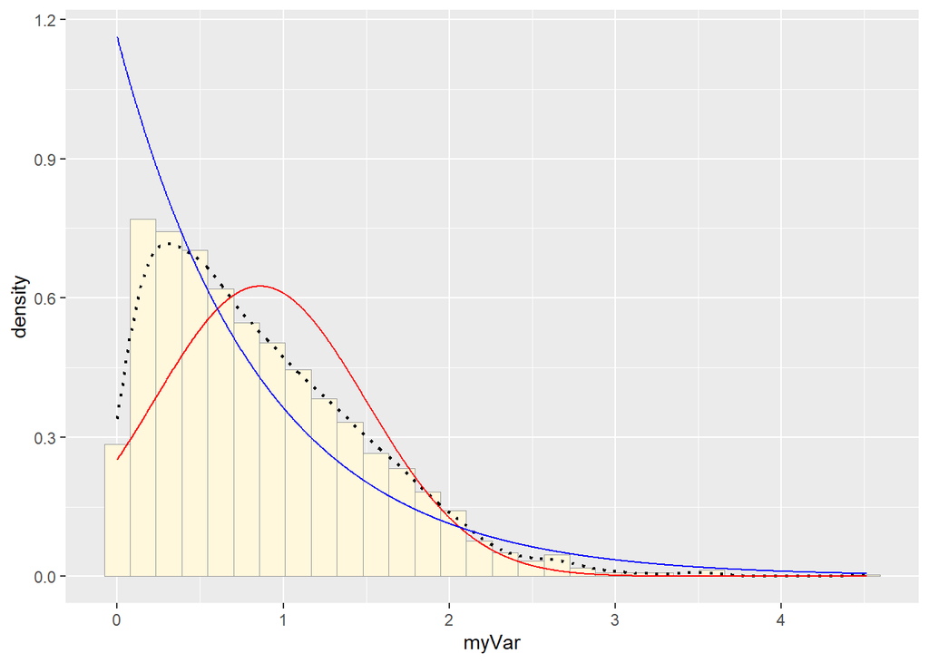

```r
expoPars <- fitdistr(z$myVar, "exponential")
rateML <- expoPars$estimate["rate"]
stat2 <- stat_function(aes(x=xval, y=..y..), fun=dexp,
                       color="blue", n=length(z$myVar),
                       args=list(rate=rateML))
p1 + stat + stat2
```

## Plot uniform probability density

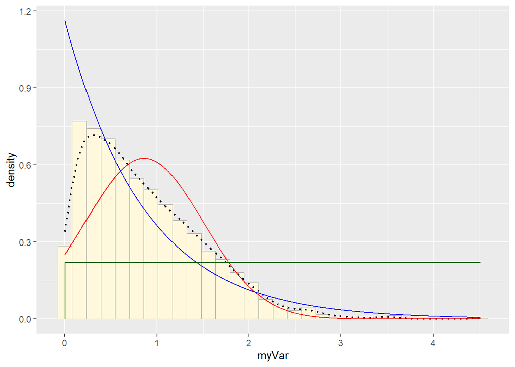

```r
stat3 <- stat_function(aes(x=xval, y=..y..), fun=dunif,
                       color="darkgreen",n=length(z$myVar),
                       args=list(min=min(z$myVar),
                                 max=max(z$myVar)))
p1 + stat + stat2 + stat3
```

## Plot gamma probability density

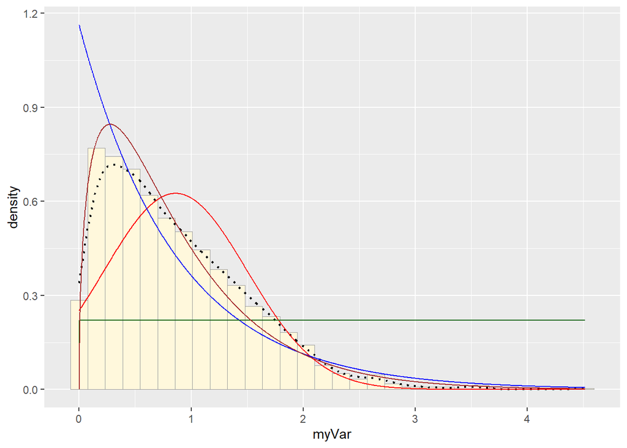

```r
gammaPars <- fitdistr(z$myVar, "gamma")
shapeML <- gammaPars$estimate["shape"]
rateML <- gammaPars$estimate["rate"]
stat4 <- stat_function(aes(x=xval, y=..y..), fun=dgamma,
                       color="brown", n=length(z$myVar),
                       args=list(shape=shapeML,
                                 rate=rateML))
p1 + stat + stat2 + stat3 + stat4
```

## Plot beta probability density

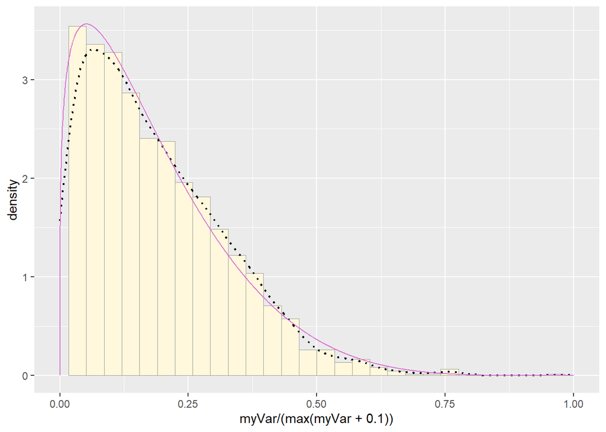

```r
pSpecial <- ggplot(data=z, aes(x=myVar/(max(myVar+0.1)),
                               y=..density..)) +
  geom_histogram(color="grey60", fill="cornsilk",
                 size=0.2) +
  xlim(c(0,1)) +
  geom_density(size=0.75, linetype="dotted")

betaPars <- fitdistr(x=z$myVar/max(z$myVar+0.1),
                     start=list(shape1=1, shape2=2),
                     "beta")
shape1ML <- betaPars$estimate["shape1"]
shape2ML <- betaPars$estimate["shape2"]

statSpecial <- stat_function(aes(x=xval, y=..y..),
                             fun=dbeta, color="orchid",
                             n=length(z$myVar),
                             args=list(shape1=shape1ML,
                                       shape2=shape2ML))
pSpecial + statSpecial
```

# Inputting my own data

```r
z <- read.table("CleanData.csv", header=TRUE, sep=",")
str(z)
```

```
## 'data.frame':    49 obs. of  6 variables:
##  $ Genotype : chr  "VT5" "VT12" "CH" "VT5" ...
##  $ Region   : chr  "Temperate" "Temperate" "Tropical" "Temperate" ...
##  $ Treatment: chr  "Control" "Control" "Control" "Control" ...
##  $ Intensity: num  38733 24251 36401 71507 34806 ...
##  $ Latitude : num  44.4 44.4 16.7 44.4 44.4 ...
##  $ LT50     : num  34.8 34.2 36.2 34.8 34.2 ...
```

```r
summary(z)
```

```
##    Genotype            Region           Treatment           Intensity
##  Length:49          Length:49          Length:49          Min.   : 13464
##  Class :character   Class :character   Class :character   1st Qu.: 50185
##  Mode  :character   Mode  :character   Mode  :character   Median : 71507
##                                                           Mean   : 65281
##                                                           3rd Qu.: 78849
##                                                           Max.   :112951
##     Latitude          LT50
##  Min.   : 5.56   Min.   :34.03
##  1st Qu.:16.70   1st Qu.:34.23
##  Median :35.76   Median :35.11
##  Mean   :30.08   Mean   :35.28
##  3rd Qu.:44.37   3rd Qu.:36.14
##  Max.   :44.37   Max.   :36.24
```

## Plot histogram of data

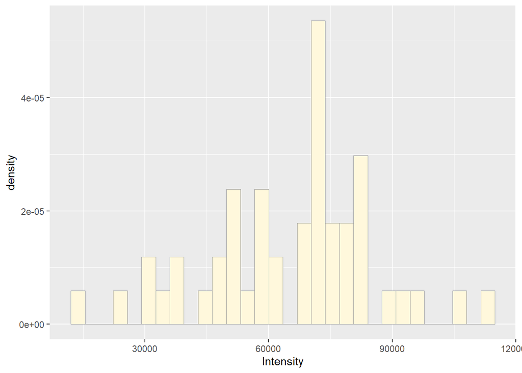

```r
p1 <- ggplot(data=z, aes(x=Intensity, y=..density..)) +
  geom_histogram(color="grey60", fill="cornsilk",
                 linewidth=0.2)
print(p1)
```

## Add empirical density curve

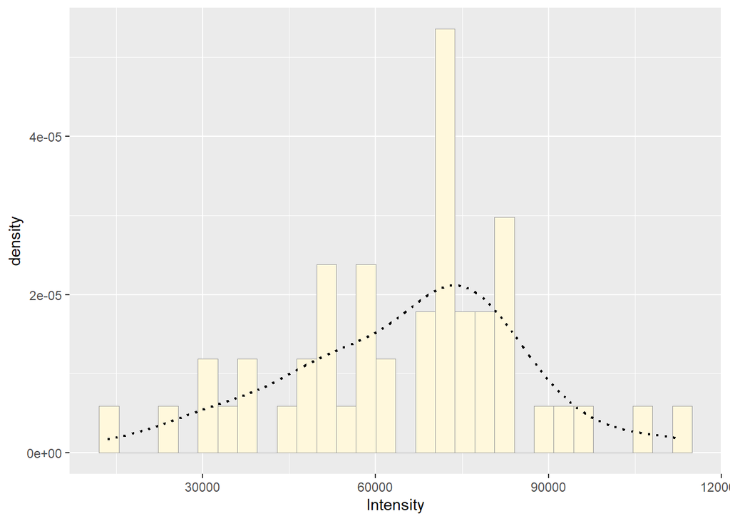

```r
p1 <- p1 + geom_density(linetype="dotted", size=0.75)
print(p1)
```

## Get maximum likelihood parameters for normal

```r
normPars <- fitdistr(z$Intensity, "normal")
print(normPars)
```

```
##      mean         sd
##   65281.071   20297.047
##  ( 2899.578) ( 2050.311)
```

```r
str(normPars)
```

```
## List of 5
##  $ estimate: Named num [1:2] 65281 20297
##   ..- attr(*, "names")= chr [1:2] "mean" "sd"
##  $ sd      : Named num [1:2] 2900 2050
##   ..- attr(*, "names")= chr [1:2] "mean" "sd"
##  $ vcov    : num [1:2, 1:2] 8407553 0 0 4203777
##   ..- attr(*, "dimnames")=List of 2
##   .. ..$ : chr [1:2] "mean" "sd"
##   .. ..$ : chr [1:2] "mean" "sd"
##  $ n       : int 49
##  $ loglik  : num -556
##  - attr(*, "class")= chr "fitdistr"
```

```r
normPars$estimate["mean"]
```

```
##     mean
## 65281.07
```

## Plot normal probability density

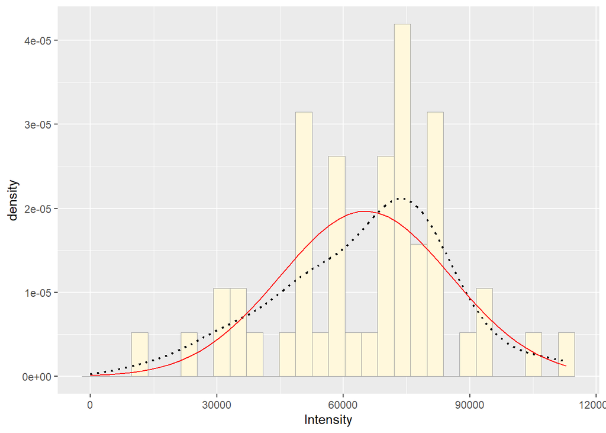

```r
meanML <- normPars$estimate["mean"]
sdML <- normPars$estimate["sd"]
xval <- seq(0,max(z$Intensity),
            len=length(z$Intensity))
stat <- stat_function(aes(x=xval, y=..y..), fun=dnorm,
                      color="red",
                      n=length(z$Intensity),
                      args=list(mean=meanML, sd=sdML))
p1 + stat
```

## Plot exponential probability density

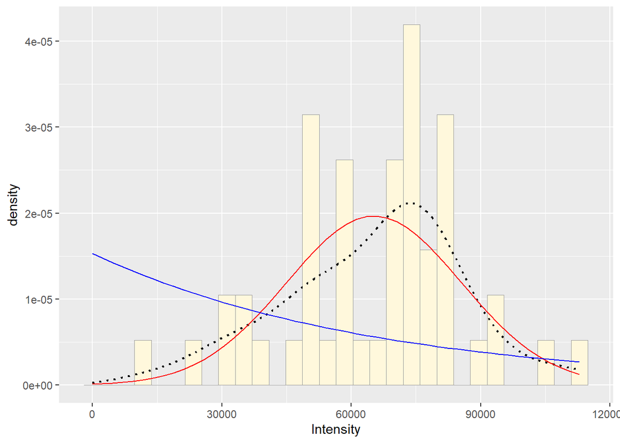

```r
expoPars <- fitdistr(z$Intensity, "exponential")
rateML <- expoPars$estimate["rate"]
stat2 <- stat_function(aes(x=xval, y=..y..), fun=dexp,
                       color="blue",
                       n=length(z$Intensity),
                       args=list(rate=rateML))
p1 + stat + stat2
```

## Plot uniform probability density

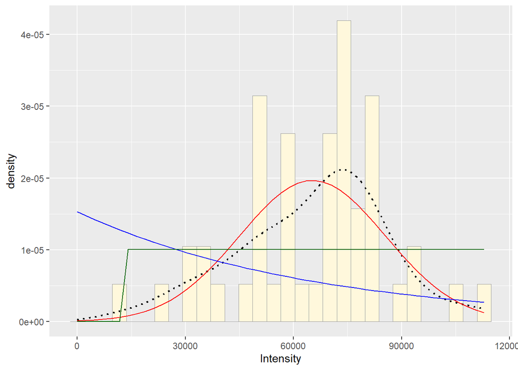

```r
stat3 <- stat_function(aes(x=xval, y=..y..), fun=dunif,
                    color="darkgreen",
                    n=length(z$Intensity),
                       args=list(min=min(z$Intensity),
                                 max=max(z$Intensity)))
p1 + stat + stat2 + stat3
```

## Plot gamma probability density

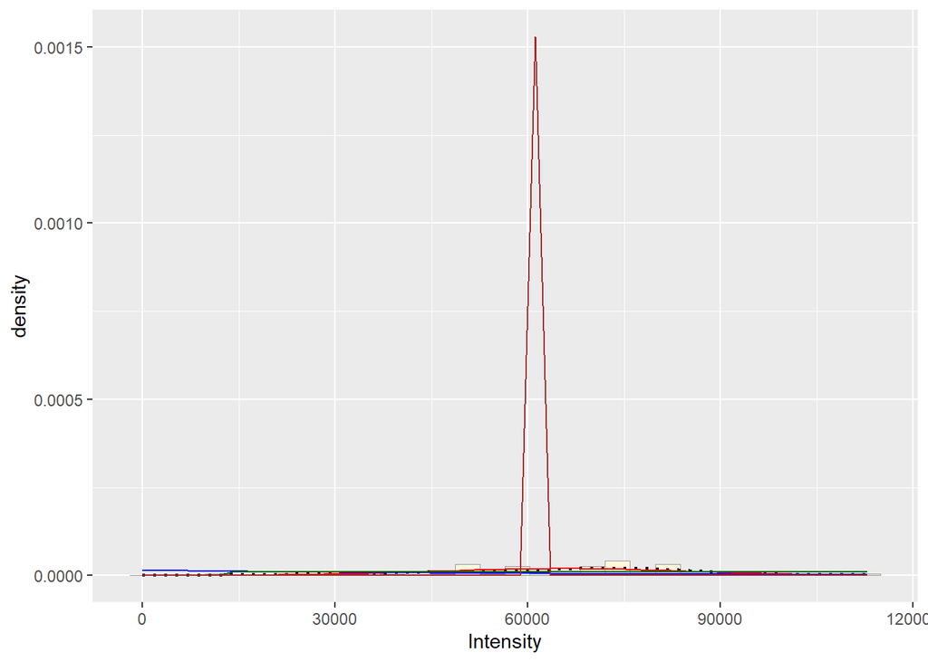

```r
gammaPars <- fitdistr(z$Intensity, "gamma",
                      start=list(shape = 1, rate =1),
                      lower=1)
shapeML <- gammaPars$estimate["shape"]
rateML <- gammaPars$estimate["rate"]
stat4 <- stat_function(aes(x=xval, y=..y..), fun=dgamma,
                       color="brown", n=length(z$Intensity),
                       args=list(shape=shapeML,
                                 rate=rateML))
p1 + stat + stat2 + stat3 + stat4
```

## Plot beta probability density

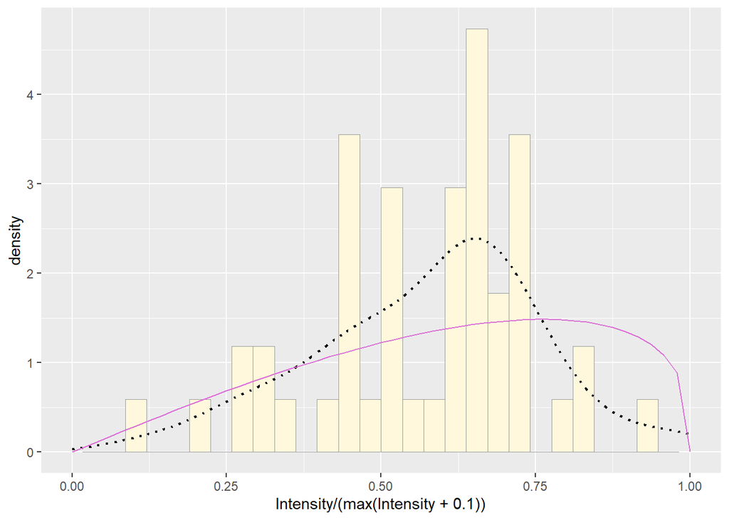

```r
pSpecial <- ggplot(data=z, aes(x=Intensity/(max(Intensity+0.1)),
                               y=..density..)) +
  geom_histogram(color="grey60", fill="cornsilk", size=0.2) +
  xlim(c(0,1)) +
  geom_density(size=0.75, linetype="dotted")

betaPars <- fitdistr(x=z$Intensity/max(z$Intensity+0.1),
                     start=list(shape1=1, shape2=2),
                     "beta")
shape1ML <- betaPars$estimate["shape1"]
shape2ML <- betaPars$estimate["shape2"]

statSpecial <- stat_function(aes(x=xval, y=..y..),
                             fun=dbeta, color="orchid",
                             n=length(z$Intensity),
                             args=list(shape1=shape1ML,
                                       shape2=shape2ML))
pSpecial + statSpecial
```

# The normal probabilty density best models my data.

## Using the normal likelihood parameters calculated above, I will generate a new dataset that also follows this pattern.

```r
fitdistr(z$Intensity,"normal")
```

```
##      mean         sd
##   65281.071   20297.047
##  ( 2899.578) ( 2050.311)
```

```r
# mean = 65281, sd = 20297
mean(z$Intensity) # real mean = 65281
```

```
## [1] 65281.07
```

```r
sd(z$Intensity) # real sd = 20507
```

```
## [1] 20507.38
```

```r
# generate the new data based on old parameters
NewData <- rnorm(n=49, mean=65281, sd=20297)
NewData <- data.frame(1:49, NewData)
names(NewData) <- list("ID", "Intensity")
str(NewData)
```

```
## 'data.frame':    49 obs. of  2 variables:
##  $ ID       : int  1 2 3 4 5 6 7 8 9 10 ...
##  $ Intensity: num  79335 92803 52219 36423 79896 ...
```

```r
summary(NewData$Intensity)
```

```
##    Min. 1st Qu.  Median    Mean 3rd Qu.    Max.
##   16336   47951   61126   62484   74827  104444
```

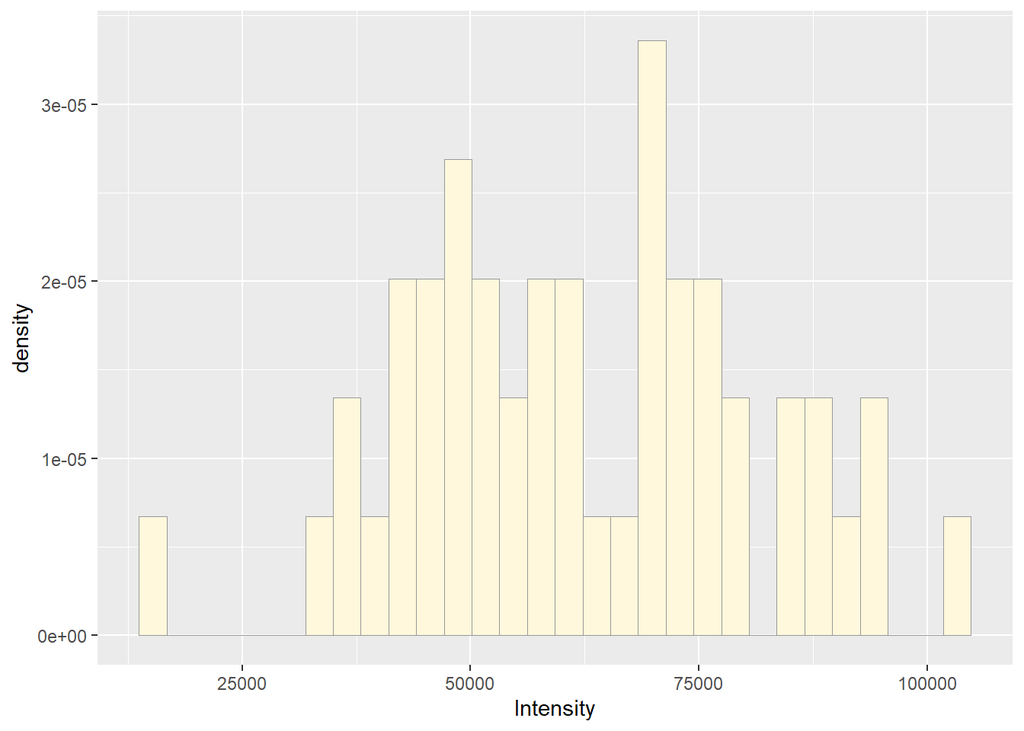

```r
# plot the new data in a histogram
NormPlot <- ggplot(data=NewData, aes(x=Intensity, y=..density..)) +
  geom_histogram(color="grey60", fill="cornsilk",
                 linewidth=0.2)
print(NormPlot)
```

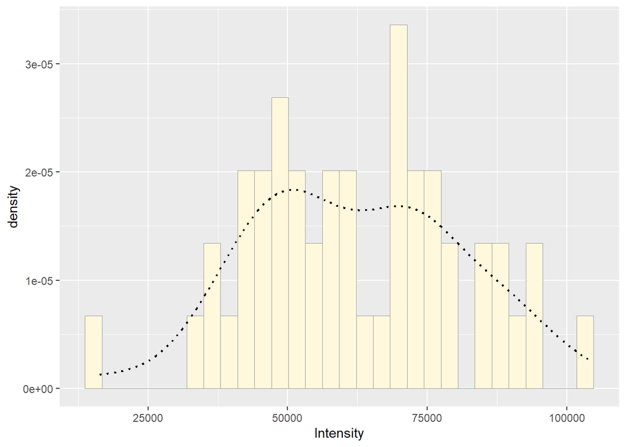

```r
# add the empirical density of the new data
NormPlot <- NormPlot + geom_density(linetype="dotted", size=0.75)
print(NormPlot)
```

```r
# generate maximum likelihood parameters for new data
NewPars <- fitdistr(NewData$Intensity, "normal")
print(normPars)
```

```
##      mean         sd
##   65281.071   20297.047
##  ( 2899.578) ( 2050.311)
```

```r
str(normPars)
```

```
## List of 5
##  $ estimate: Named num [1:2] 65281 20297
##   ..- attr(*, "names")= chr [1:2] "mean" "sd"
##  $ sd      : Named num [1:2] 2900 2050
##   ..- attr(*, "names")= chr [1:2] "mean" "sd"
##  $ vcov    : num [1:2, 1:2] 8407553 0 0 4203777
##   ..- attr(*, "dimnames")=List of 2
##   .. ..$ : chr [1:2] "mean" "sd"
##   .. ..$ : chr [1:2] "mean" "sd"
##  $ n       : int 49
##  $ loglik  : num -556
##  - attr(*, "class")= chr "fitdistr"
```

```r
NewPars$estimate["mean"]
```

```
##     mean
## 62484.31
```

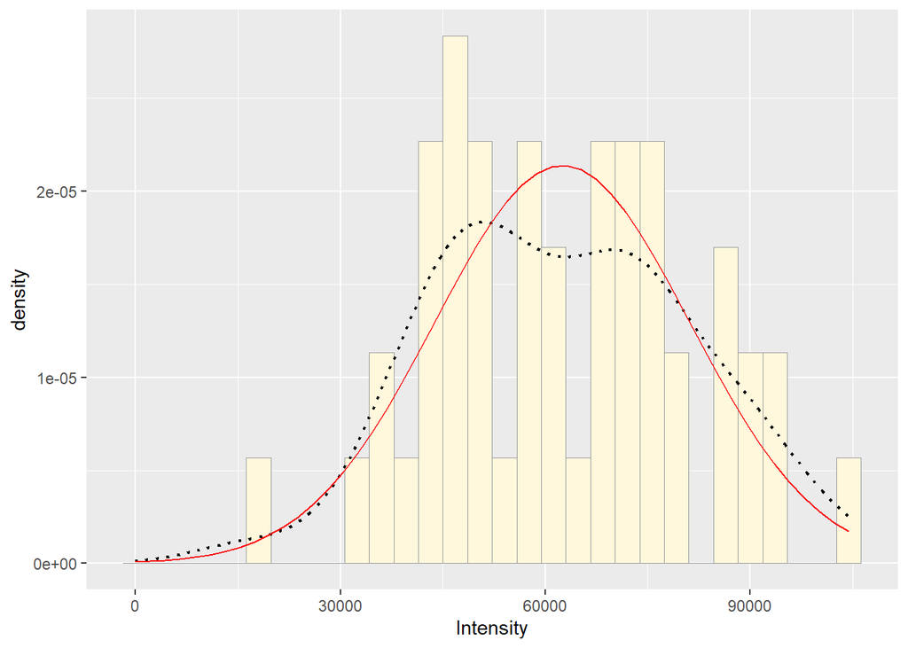

```r
# plot normal probability density for new data
NewMean <- NewPars$estimate["mean"]
NewSD <- NewPars$estimate["sd"]
NewXval <- seq(0,max(NewData$Intensity),
            len=length(NewData$Intensity))
NewStat <- stat_function(aes(x=NewXval, y=..y..), fun=dnorm,
                      color="red",
                      n=length(NewData$Intensity),
                      args=list(mean=NewMean, sd=NewSD))
NormPlot + NewStat
```

## The two histograms look very similar, but my real dataset has more variation than the simulated dataset. The probability density is higher in the simulated dataset for values around the mean. There are also fewer outliers and gaps in the simulated dataset than in my real dataset. I think the simulated dataset’s histogram is doing a good job representing the probability distribution of my real data, but the standard deviation calculated by the normal probability distribution (20297) was lower than the actual calculated value (20507) and since the simulated dataset was created based on the probability values and not the real calculated values, this could explain the lack of variation seen in my simulated histogram as compared to the higher variation seen in my real data histogram. If I were to alter the parameters of the simulated dataset, I would use the real calculated standard deviation instead of that of the model to try to make the simulated dataset more realistic.